# Elias 3o4p O-N-C ILE_0_0.1_8

## Sample=3o4p-A:262:O-A:6:N-A:262:C

| pdb_code | central atom | ca density | parallel atom | pa density | planar atom | pl density |
| --- | --- | --- | --- | --- | --- | --- |
| 3o4p | [2.99, -11.64, 27.52] | 21.9405 | [2.9, -9.64, 29.61] | 20.6952 | [3.01, -11.79, 26.32] | 17.1766 |

Sliced x-wise

Sliced y-wise

Sliced z-wise

40/81

40/81

40/81

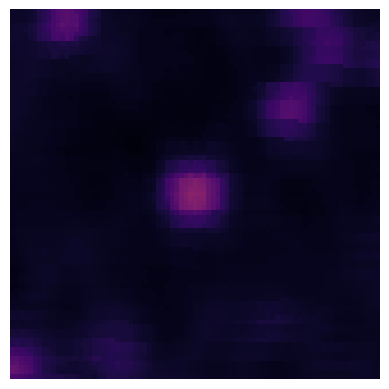

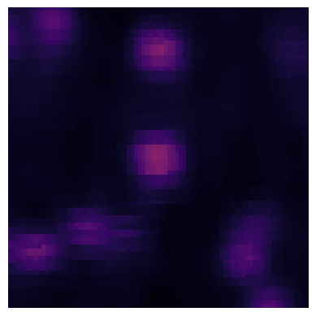

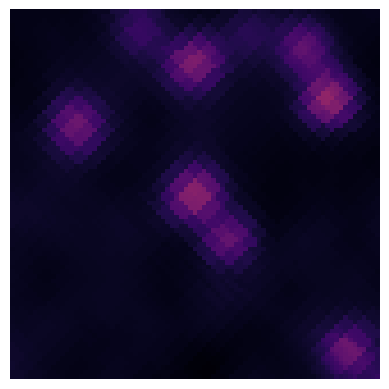

## Sample=3o4p-A:290:O-A:17:N-A:290:C

| pdb_code | central atom | ca density | parallel atom | pa density | planar atom | pl density |
| --- | --- | --- | --- | --- | --- | --- |
| 3o4p | [12.68, -4.53, 31.52] | 26.2642 | [12.5, -5.49, 28.68] | 23.4314 | [12.12, -4.41, 32.61] | 21.1197 |

Sliced x-wise

Sliced y-wise

Sliced z-wise

40/81

40/81

40/81

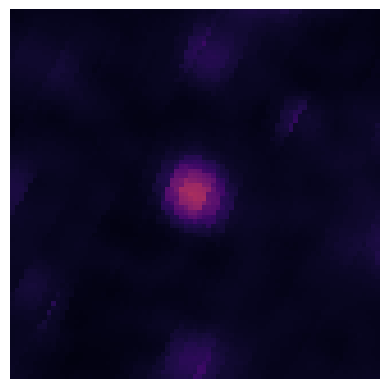

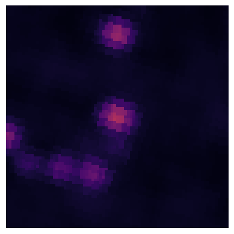

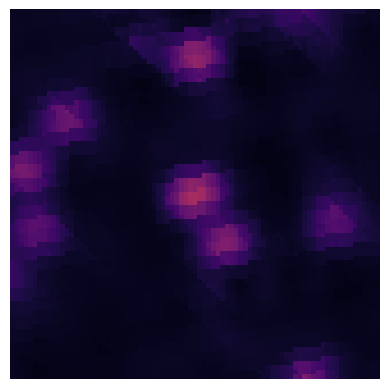

## Sample=3o4p-A:49:O-A:33:N-A:49:C

| pdb_code | central atom | ca density | parallel atom | pa density | planar atom | pl density |
| --- | --- | --- | --- | --- | --- | --- |
| 3o4p | [8.3, 1.88, 33.42] | 24.0679 | [8.47, -0.08, 31.4] | 21.9158 | [8.56, 2.81, 34.19] | 19.2892 |

Sliced x-wise

Sliced y-wise

Sliced z-wise

40/81

40/81

40/81

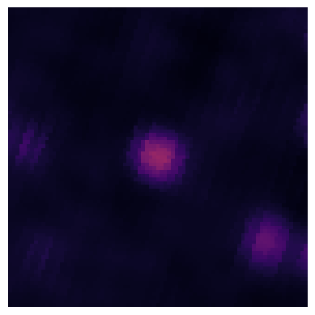

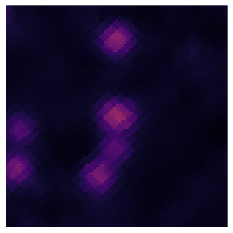

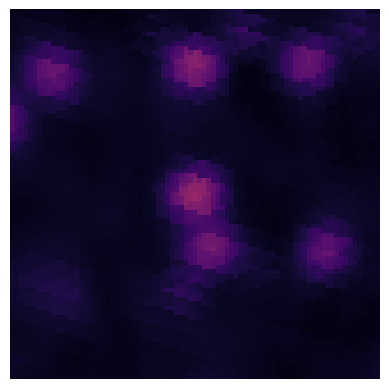

## Sample=3o4p-A:62:O-A:48:N-A:62:C

| pdb_code | central atom | ca density | parallel atom | pa density | planar atom | pl density |
| --- | --- | --- | --- | --- | --- | --- |
| 3o4p | [15.92, -7.17, 31.42] | 26.4868 | [13.92, -8.04, 33.34] | 21.2349 | [16.42, -7.1, 30.27] | 20.4994 |

Sliced x-wise

Sliced y-wise

Sliced z-wise

40/81

40/81

40/81

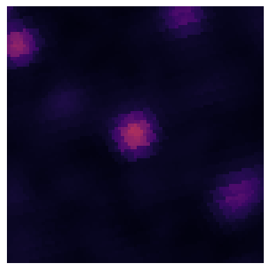

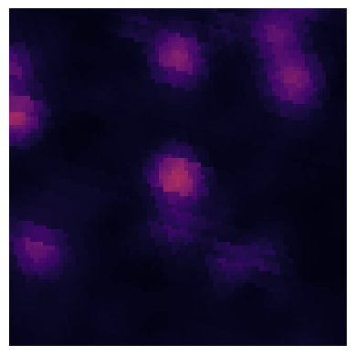

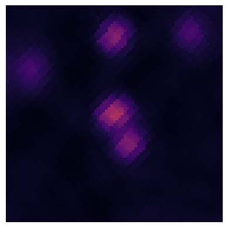

## Sample=3o4p-A:31:O-A:51:N-A:31:C

| pdb_code | central atom | ca density | parallel atom | pa density | planar atom | pl density |
| --- | --- | --- | --- | --- | --- | --- |
| 3o4p | [10.18, -1.15, 33.33] | 27.6752 | [10.82, -0.97, 36.12] | 23.6777 | [10.19, -1.56, 32.15] | 20.8242 |

Sliced x-wise

Sliced y-wise

Sliced z-wise

40/81

40/81

40/81

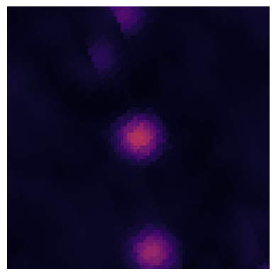

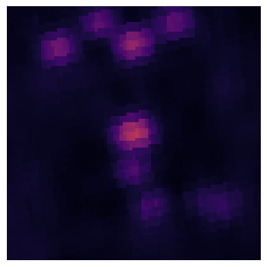

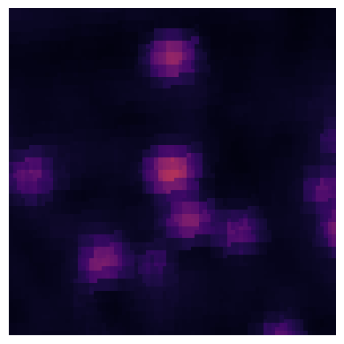

## Sample=3o4p-A:48:O-A:61:N-A:48:C

| pdb_code | central atom | ca density | parallel atom | pa density | planar atom | pl density |
| --- | --- | --- | --- | --- | --- | --- |
| 3o4p | [12.62, 10.9, 24.17] | 24.0814 | [13.35, 13.44, 25.2] | 15.8195 | [12.55, 9.72, 23.79] | 19.6681 |

Sliced x-wise

Sliced y-wise

Sliced z-wise

40/81

40/81

40/81

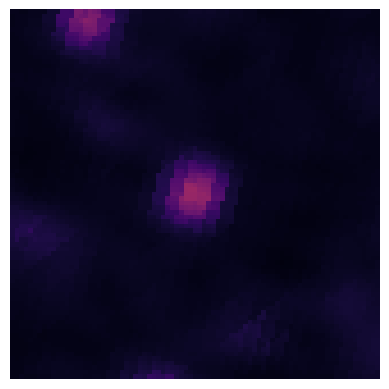

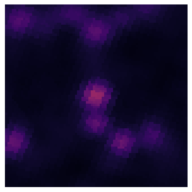

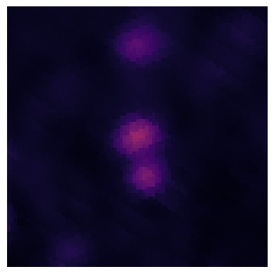

## Sample=3o4p-A:94:O-A:106:N-A:94:C

| pdb_code | central atom | ca density | parallel atom | pa density | planar atom | pl density |
| --- | --- | --- | --- | --- | --- | --- |
| 3o4p | [15.66, 8.64, 12.42] | 29.5216 | [15.18, 6.19, 13.79] | 26.4288 | [15.43, 9.85, 12.32] | 21.5086 |

Sliced x-wise

Sliced y-wise

Sliced z-wise

40/81

40/81

40/81

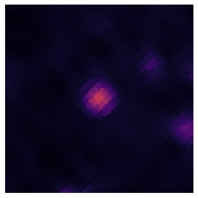

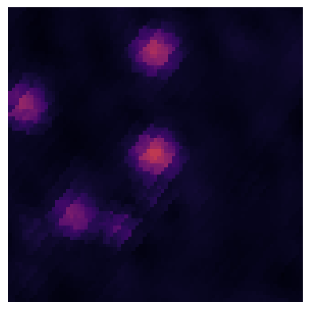

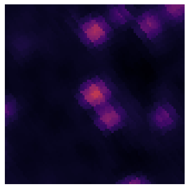

## Sample=3o4p-A:156:O-A:132:N-A:156:C

| pdb_code | central atom | ca density | parallel atom | pa density | planar atom | pl density |
| --- | --- | --- | --- | --- | --- | --- |
| 3o4p | [10.0, 10.9, 7.44] | 27.0148 | [10.28, 9.02, 9.67] | 23.7925 | [10.14, 10.86, 6.23] | 18.4329 |

Sliced x-wise

Sliced y-wise

Sliced z-wise

40/81

40/81

40/81

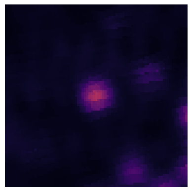

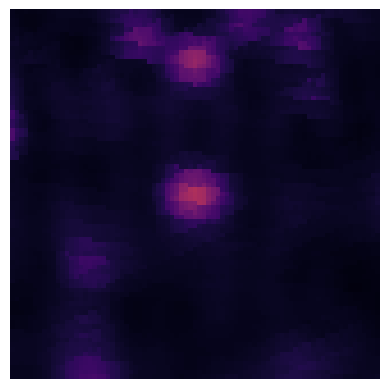

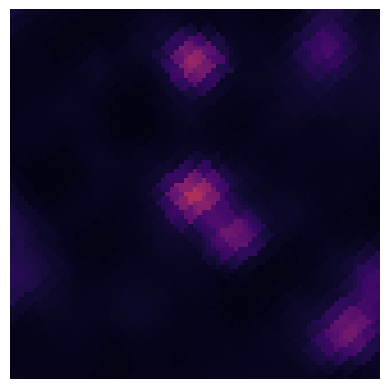

## Sample=3o4p-A:168:O-A:155:N-A:168:C

| pdb_code | central atom | ca density | parallel atom | pa density | planar atom | pl density |
| --- | --- | --- | --- | --- | --- | --- |
| 3o4p | [18.05, 12.62, 13.78] | 25.757 | [16.36, 14.98, 13.54] | 22.5526 | [18.09, 11.41, 13.98] | 20.2971 |

Sliced x-wise

Sliced y-wise

Sliced z-wise

40/81

40/81

40/81

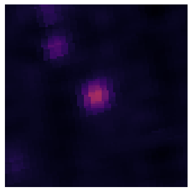

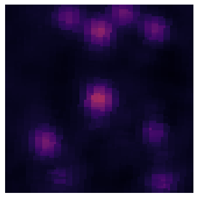

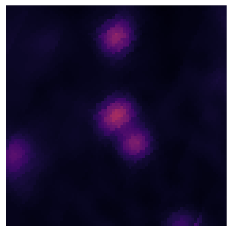

## Sample=3o4p-A:157:O-A:165:N-A:157:C

| pdb_code | central atom | ca density | parallel atom | pa density | planar atom | pl density |
| --- | --- | --- | --- | --- | --- | --- |
| 3o4p | [18.68, -0.45, 9.26] | 27.0106 | [17.37, -0.08, 6.71] | 24.2751 | [19.05, -1.01, 10.3] | 22.514 |

Sliced x-wise

Sliced y-wise

Sliced z-wise

40/81

40/81

40/81

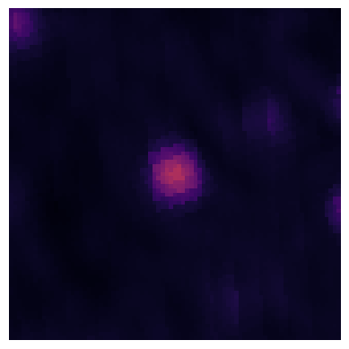

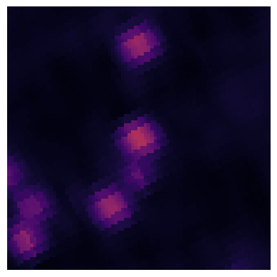

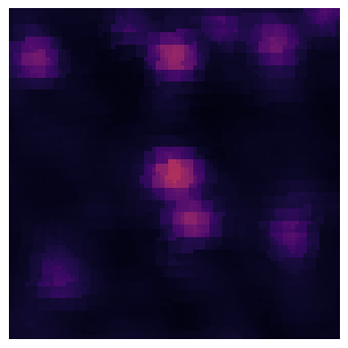

## Sample=3o4p-A:178:O-A:191:N-A:178:C

| pdb_code | central atom | ca density | parallel atom | pa density | planar atom | pl density |
| --- | --- | --- | --- | --- | --- | --- |
| 3o4p | [24.09, 2.42, 3.06] | 23.2345 | [22.78, 5.04, 3.25] | 22.2887 | [24.44, 1.92, 4.11] | 19.0448 |

Sliced x-wise

Sliced y-wise

Sliced z-wise

40/81

40/81

40/81

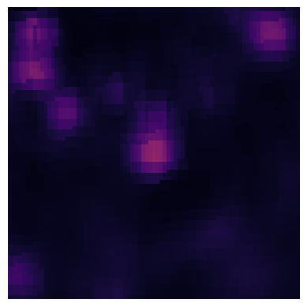

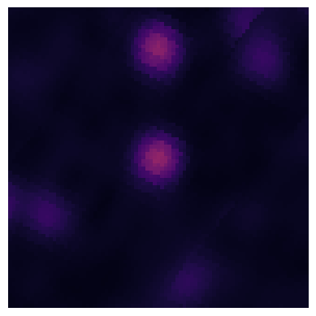

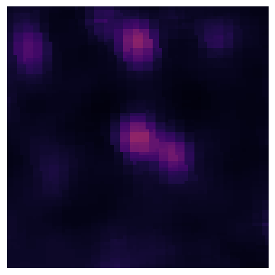

## Sample=3o4p-A:188:O-A:205:N-A:188:C

| pdb_code | central atom | ca density | parallel atom | pa density | planar atom | pl density |
| --- | --- | --- | --- | --- | --- | --- |
| 3o4p | [5.98, -6.55, 2.03] | 26.346 | [7.42, -9.07, 2.32] | 22.001 | [5.45, -5.72, 2.79] | 20.221 |

Sliced x-wise

Sliced y-wise

Sliced z-wise

40/81

40/81

40/81

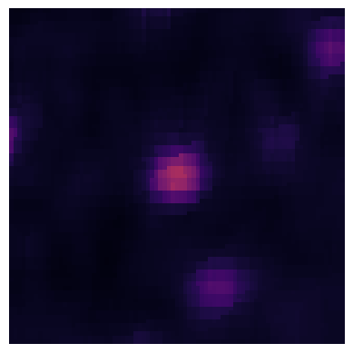

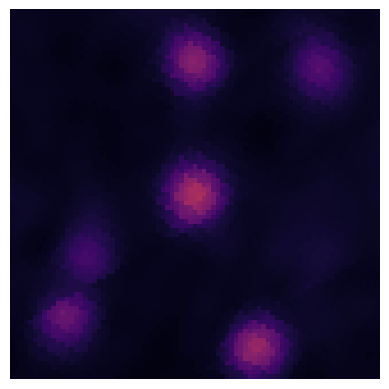

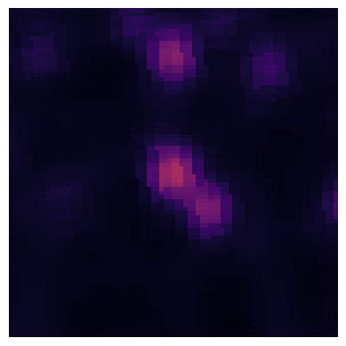

## Sample=3o4p-A:198:O-A:220:N-A:198:C

| pdb_code | central atom | ca density | parallel atom | pa density | planar atom | pl density |
| --- | --- | --- | --- | --- | --- | --- |
| 3o4p | [9.35, -18.68, 12.04] | 22.1903 | [9.08, -15.8, 11.73] | 22.7564 | [9.97, -19.73, 11.78] | 16.8765 |

Sliced x-wise

Sliced y-wise

Sliced z-wise

40/81

40/81

40/81

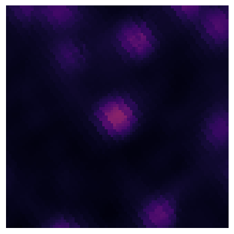

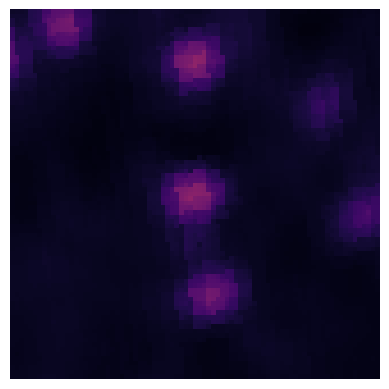

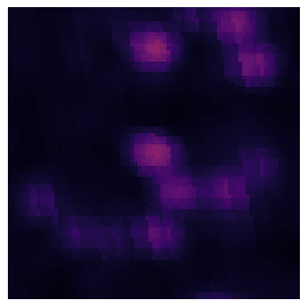

## Sample=3o4p-A:263:O-A:249:N-A:263:C

| pdb_code | central atom | ca density | parallel atom | pa density | planar atom | pl density |
| --- | --- | --- | --- | --- | --- | --- |
| 3o4p | [11.14, -16.25, 9.89] | 23.4773 | [11.32, -19.01, 9.93] | 20.2455 | [10.77, -15.1, 10.19] | 20.4071 |

Sliced x-wise

Sliced y-wise

Sliced z-wise

40/81

40/81

40/81

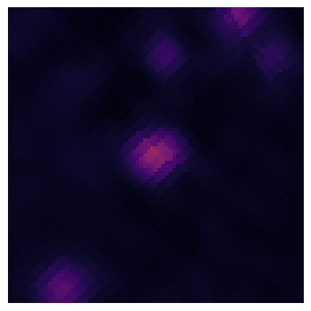

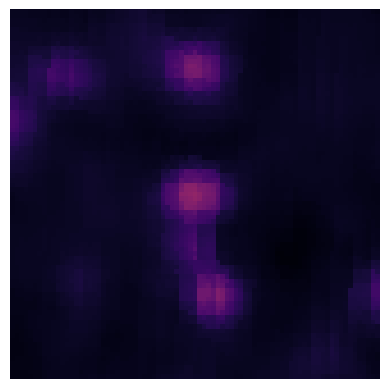

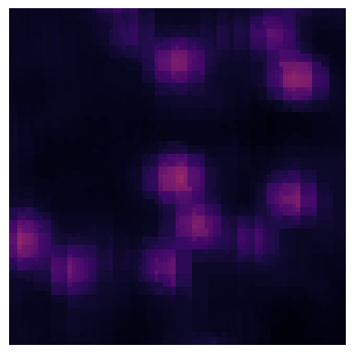

## Sample=3o4p-A:249:O-A:263:N-A:249:C

| pdb_code | central atom | ca density | parallel atom | pa density | planar atom | pl density |
| --- | --- | --- | --- | --- | --- | --- |
| 3o4p | [17.36, -18.56, 20.05] | 27.1956 | [18.28, -15.86, 20.34] | 24.6715 | [16.83, -19.68, 20.07] | 20.4307 |

Sliced x-wise

Sliced y-wise

Sliced z-wise

40/81

40/81

40/81

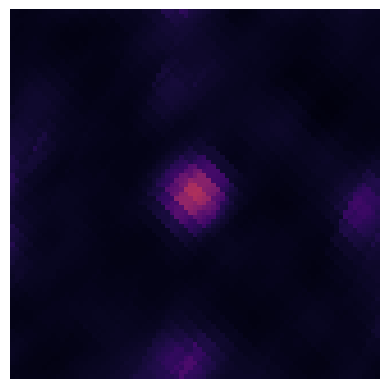

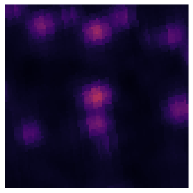

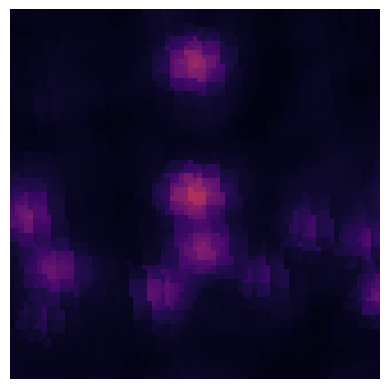

## Sum of all densities

Sliced x-wise

Sliced y-wise

Sliced z-wise

40/81

40/81

40/81

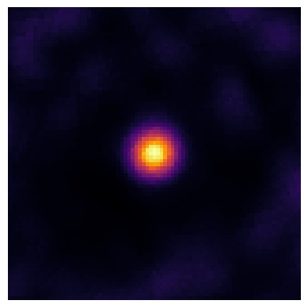

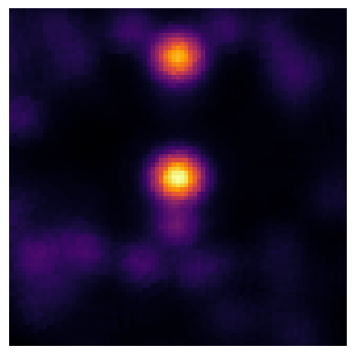

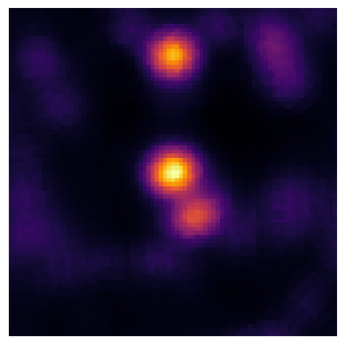

## Log-sum of all densities transformed values

Sliced x-wise

Sliced y-wise

Sliced z-wise

40/81

40/81

40/81

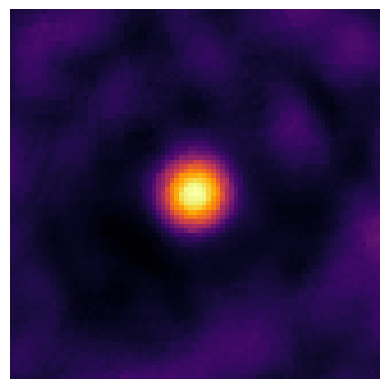

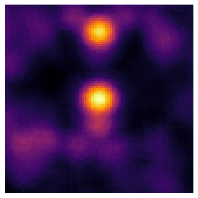

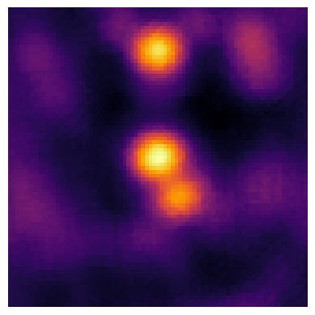